# Part I - (Ford GoBike System Data)

## Bivariate Exploration

Some relationships to explore:

> Trip duration and User type.

> Trip duration and member age.

> User Type and Day.

> User Type and Hour.

> Duration and gender.

**Trip duration based on user type**

```python
#This filtering the data based on the user type
cust_df = df['user_type']=='Customer'
subs_df = df['user_type']=='Subscriber'
```

```python
# Average trip duration for Customer
df[cust_df].duration_sec.mean()
```

```
1310.6561028612821
```

```python
# Average trip duration for Subscriber
df[subs_df].duration_sec.mean()
```

```
640.55130503958685
```

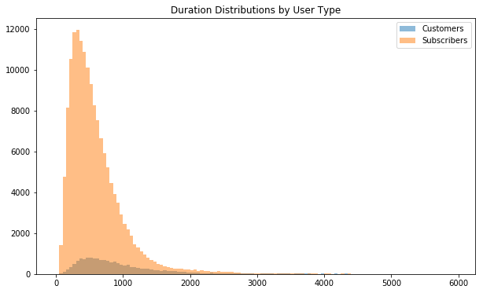

```python
#Using the histogram plots to show duration and user type
plt.figure(figsize=(10,6))
bins = np.arange(0, 6000, 50)

plt.hist(df[cust_df].duration_sec, bins, alpha=0.5, label='Customers')
plt.hist(df[subs_df].duration_sec, bins, alpha=0.5, label='Subscribers')
plt.legend(loc='upper right')
plt.title('Duration Distributions by User Type')

plt.show()
```

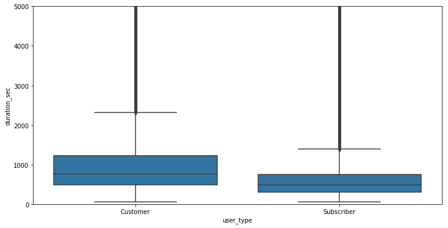

```python
#Using the box plots to represent duration and user types
plt.figure(figsize=(12,6))
plt.ylim(0, 5000) #reduced the ylim to represent the data fully
sb.boxplot(data=df, x='user_type', y='duration_sec', color=base_color);
```

**Trip duration and member age**

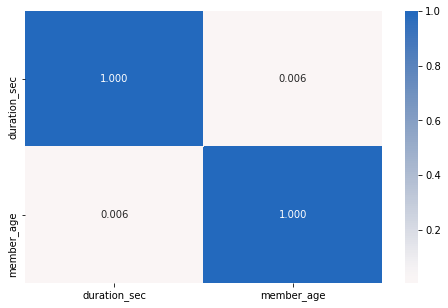

```python
# correlation plot between'duration_sec','member_age'.
numeric_vars = ['duration_sec', 'member_age']
plt.figure(figsize = [8, 5])
sb.heatmap(df[numeric_vars].corr(), annot = True, fmt = '.3f',cmap = 'vlag_r', center = 0)
plt.show()
```

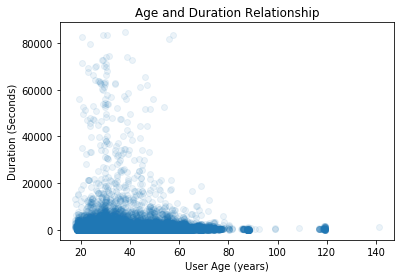

```python
#Scatter plot representation of age and duration
sb.regplot(data=df,x='member_age',y='duration_sec',fit_reg=False, x_jitter=0.4, scatter_kws={'alpha':1/12})
plt.xlabel('User Age (years)')
plt.ylabel('Duration (Seconds)')
plt.title('Age and Duration Relationship');
```

**User type and Day**

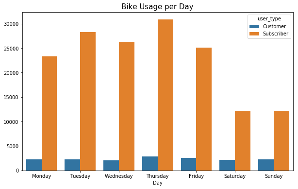

```python
plt.figure(figsize=(10,6))
plt.title('Bike Usage per Day', fontsize=15)
chart = sb.countplot(data=df, x='t_day', order=day_name, hue='user_type')
chart.set(xlabel='Day', ylabel='');
```

**User type and Hour**

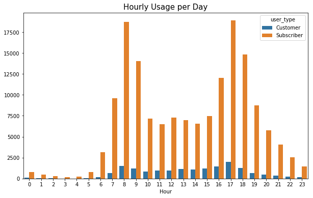

```python
plt.figure(figsize=(10,6))
plt.title('Hourly Usage per Day', fontsize=15)
chart = sb.countplot(data=df, x='t_hour', hue='user_type')

chart.set(xlabel='Hour', ylabel='');
```

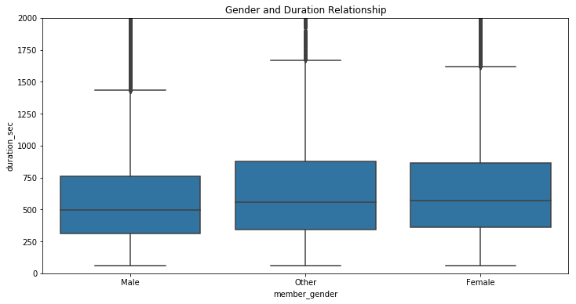

```python
#Using the boxplots to show duration and gender
plt.figure(figsize=(12,6))
plt.ylim(0, 2000)
plt.title('Gender and Duration Relationship');
sb.boxplot(data=df, x='member_gender', y='duration_sec', color=base_color);
```

### Talk about some of the relationships you observed in this part of the investigation. How did the feature(s) of interest vary with other features in the dataset?

> Customers have a more varied duration than subscribers.

### Did you observe any interesting relationships between the other features (not the main feature(s) of interest)?

> Males tend to have shorter trips than females.